# Analysis Hovering

Author

Juliette Tariel-Adam

Published

February 4, 2025

To analyse the amount of time the fish was hovering on the 204 trials with hovering time > 0, we tried:

- glm with poisson or zero-inflated poisson distribution, but the fit was not good.
- a transformation log(hovering +1), see below, but only a log(hovering+103) was good enough to achieve normal distribution. But there was a huge problem in hetereogeneity of variance with this model.
- a linear model on the remaining 204 trials during which hovering happened. But the variance of residuals was increasing with the fitted hovering time values.
- a linear model with weighted least squares to stabilise the variance accross the fitted values. The normality was not great but ANOVA are robust to the assumption of normality. It is the model we chose. We had to use the nlme package for this but it does not allow for rank deficient models.
- We tried to implement weighted least squares with the lmer package with no success.

**Poisson distribution**

Y variable = amount of time spent hovering during a trial, rounded to be an integer in seconds

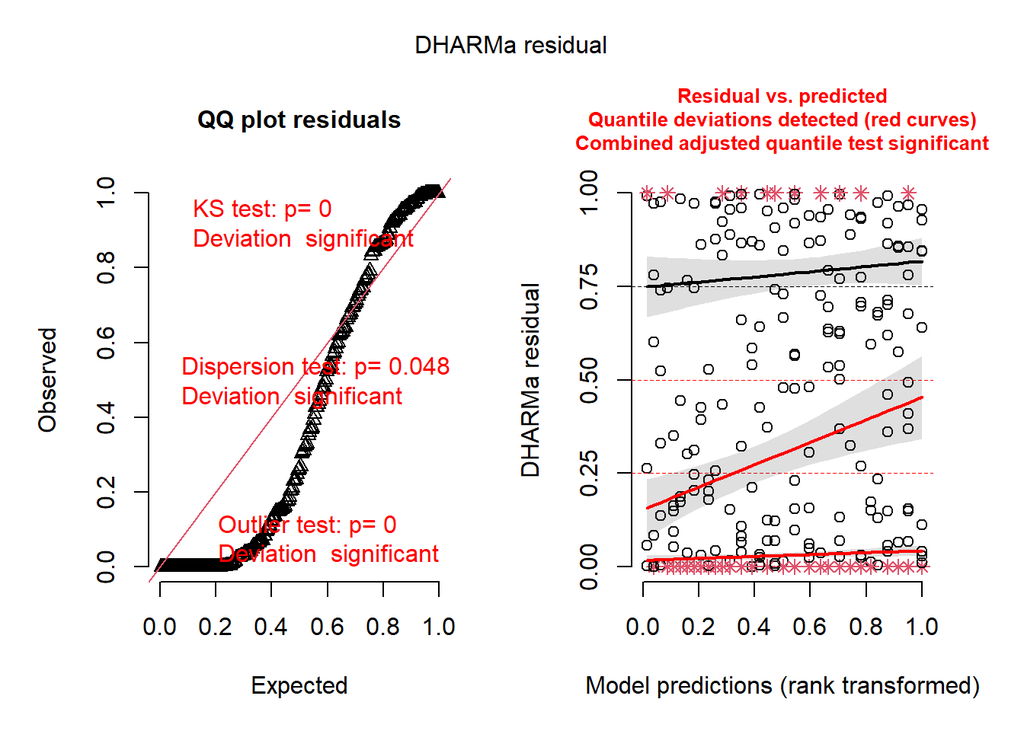

```r
# poisson on all hovering data
mHovering <- glmmTMB(round(Hovering,0) ~ Tank + Time + Filter + (1|Fish), data = data, family =poisson)
mHovering_res <- simulateResiduals(mHovering)
plot(mHovering_res)
```

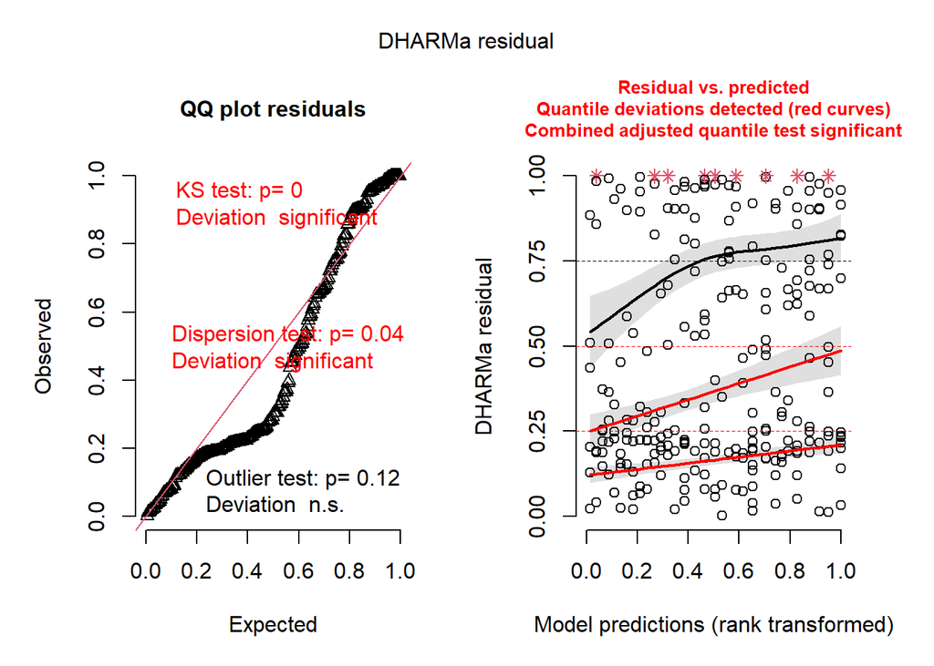

```r
# zero inflated poisson on all hovering data
mHovering <- glmmTMB(round(Hovering,0) ~ Tank + Time + Filter + (1|Fish), data = data, family =poisson,ziformula=~1)
mHovering_res <- simulateResiduals(mHovering)
plot(mHovering_res)
```

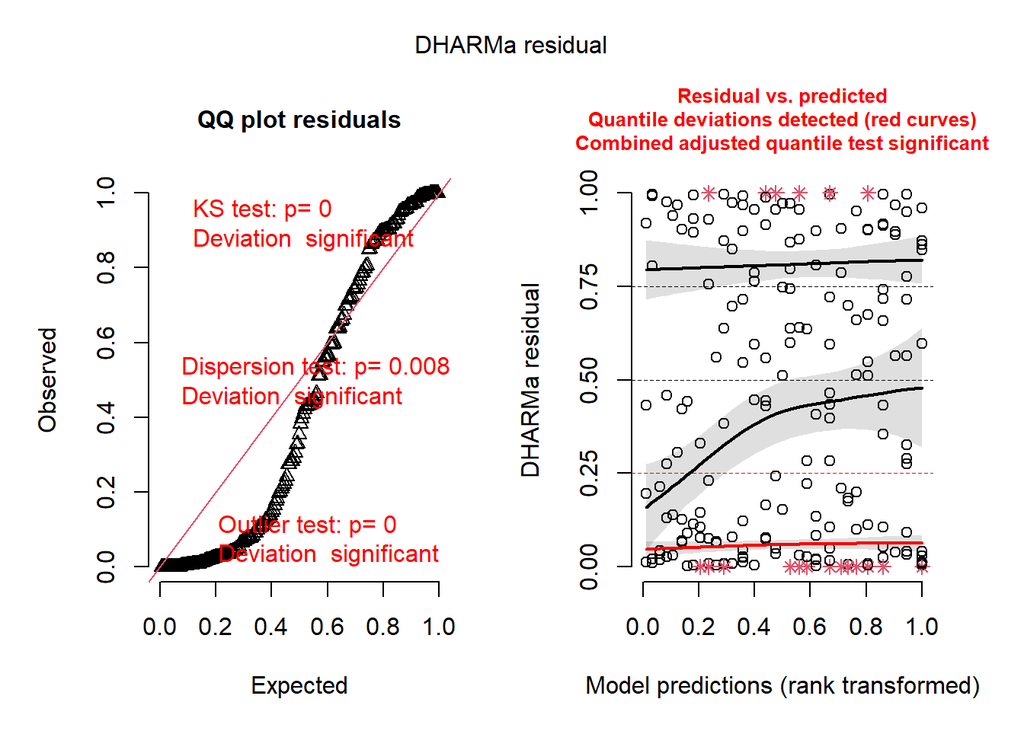

```r
# poisson without the zeros
mHovering <- glmmTMB(round(Hovering,0) ~ Tank + Time + Filter + (1|Fish), data = data[data$Hovering >0,], family =poisson)
mHovering_res <- simulateResiduals(mHovering)
plot(mHovering_res)
```

Fit are not good

**Attempt transformation log(Y + 1)**

Y variable = amount of time spent hovering during a trial.

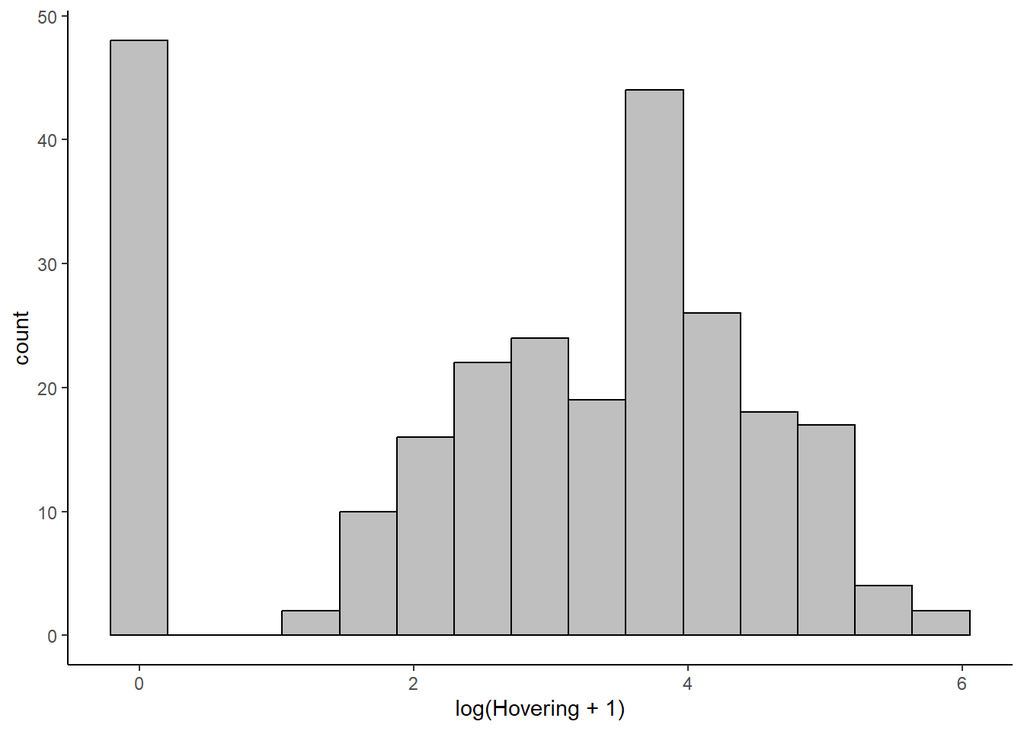

```r
ggplot(data, aes(x = log(Hovering + 1)))+
  geom_histogram(bins = 15, fill = grey(0.75), color="black")
```

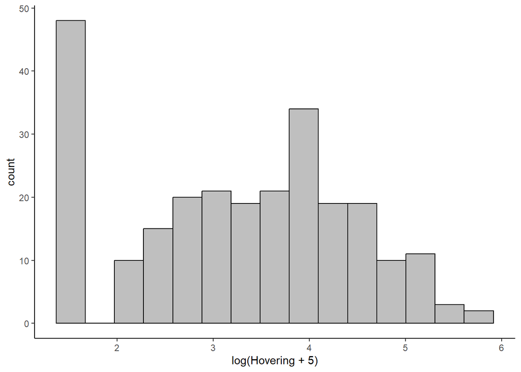

```r
ggplot(data, aes(x = log(Hovering + 5)))+
  geom_histogram(bins = 15, fill = grey(0.75), color="black")
```

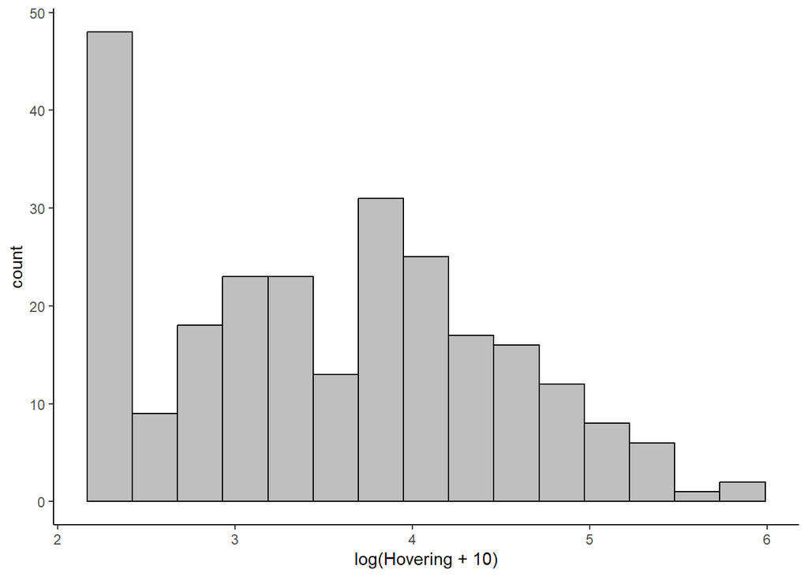

```r
ggplot(data, aes(x = log(Hovering + 10)))+
  geom_histogram(bins = 15, fill = grey(0.75), color="black")
```

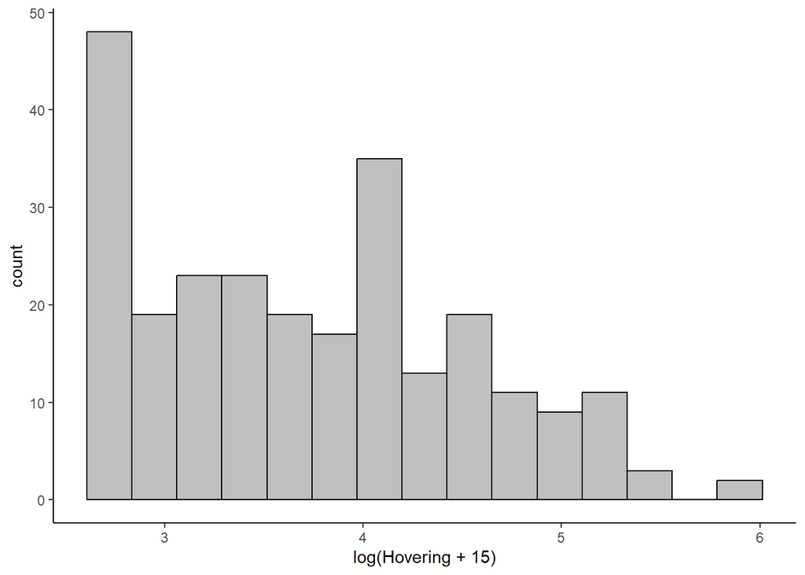

```r
ggplot(data, aes(x = log(Hovering + 15)))+
  geom_histogram(bins = 15, fill = grey(0.75), color="black")
```

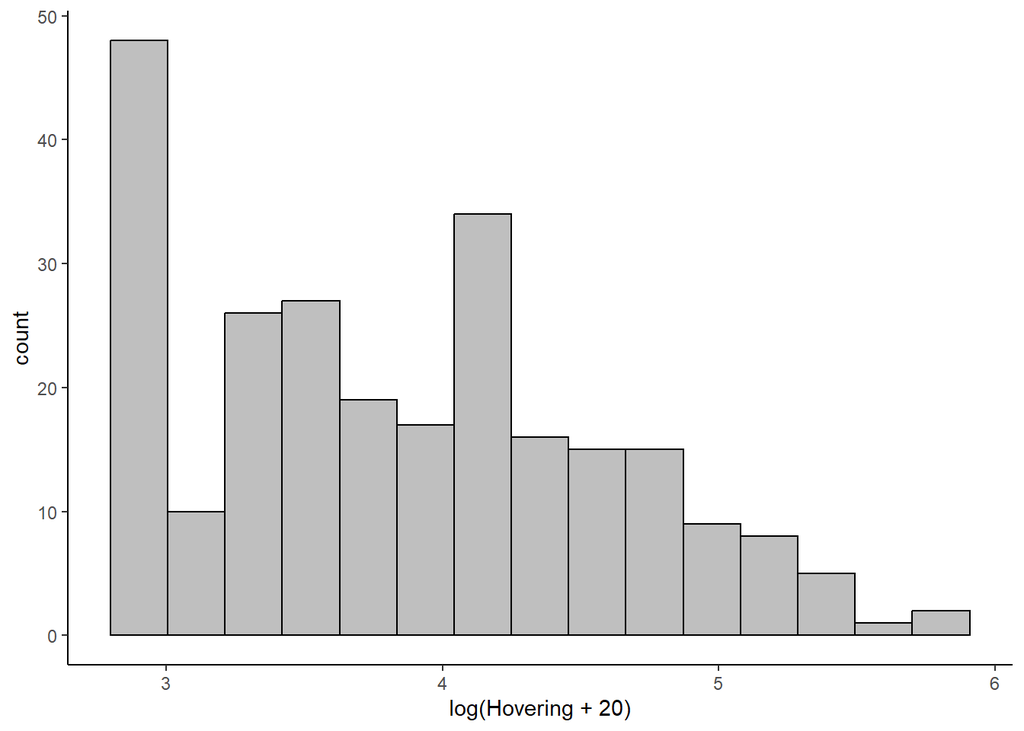

```r
ggplot(data, aes(x = log(Hovering + 20)))+
  geom_histogram(bins = 15, fill = grey(0.75), color="black")
```

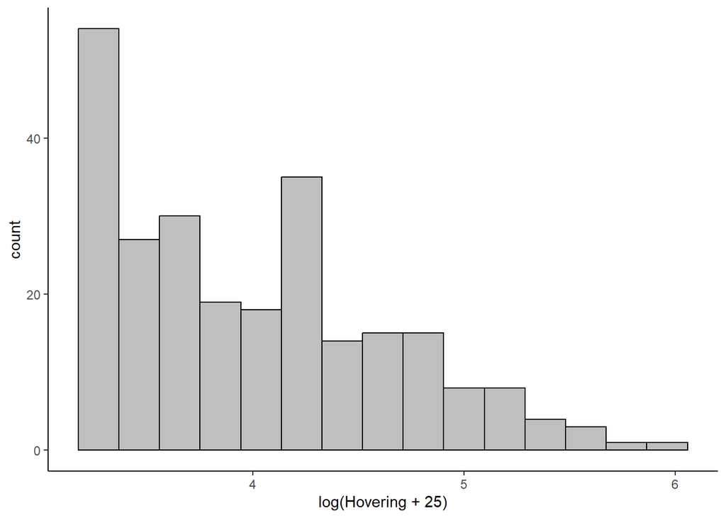

```r
ggplot(data, aes(x = log(Hovering + 25)))+
  geom_histogram(bins = 15, fill = grey(0.75), color="black")
```

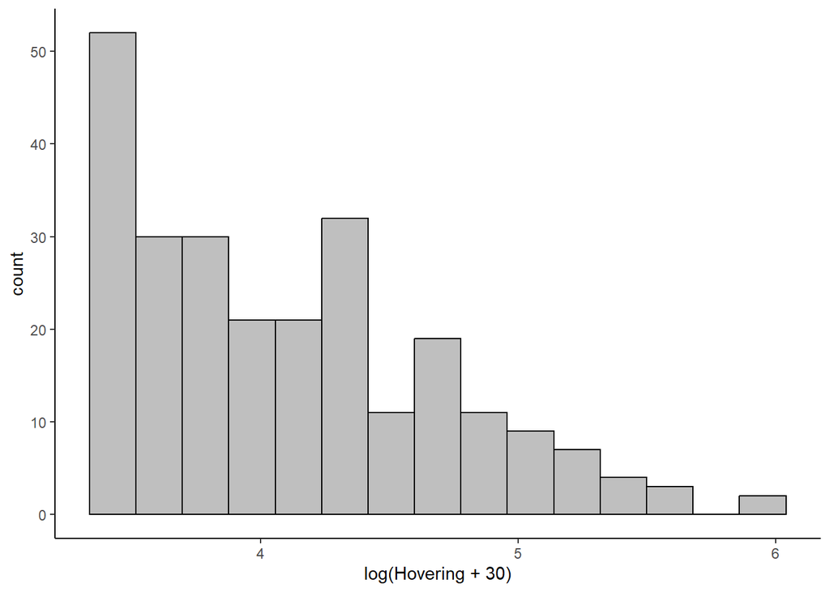

```r
ggplot(data, aes(x = log(Hovering + 30)))+
  geom_histogram(bins = 15, fill = grey(0.75), color="black")
```

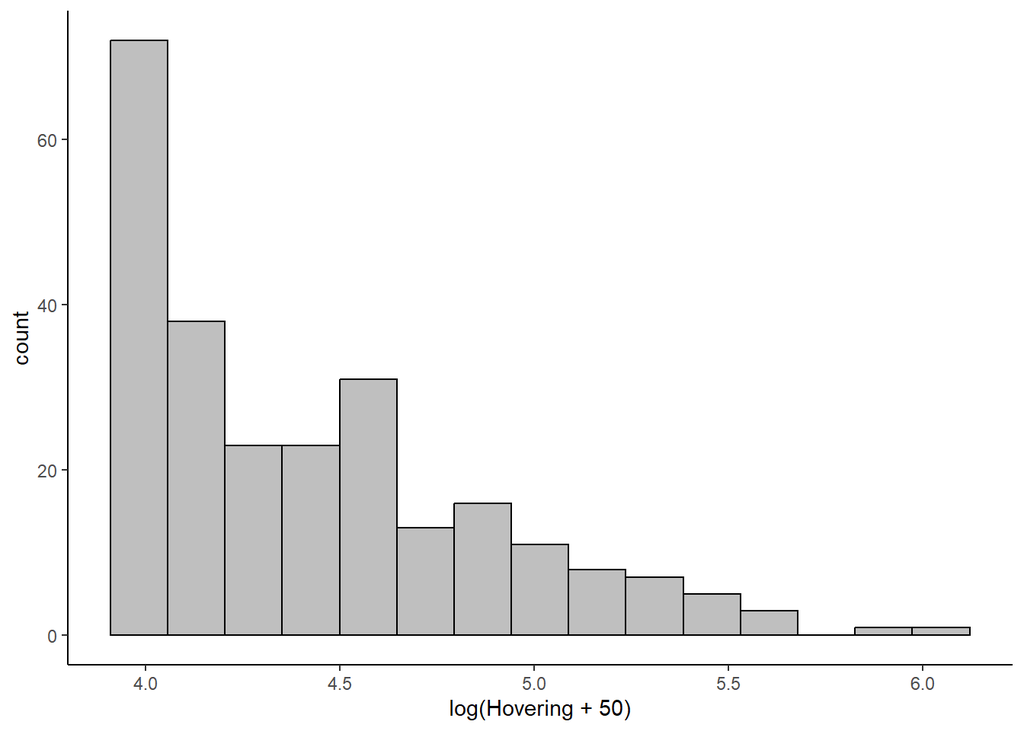

```r
ggplot(data, aes(x = log(Hovering + 50)))+
  geom_histogram(bins = 15, fill = grey(0.75), color="black")
```

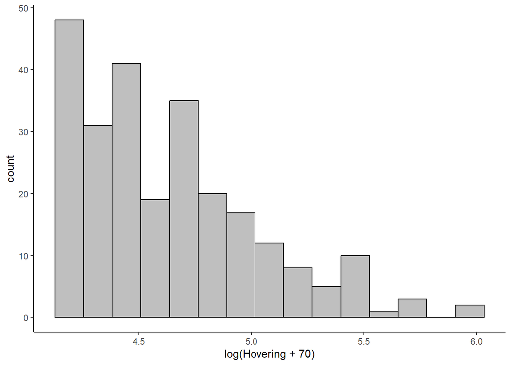

```r
ggplot(data, aes(x = log(Hovering + 70)))+
  geom_histogram(bins = 15, fill = grey(0.75), color="black")
```

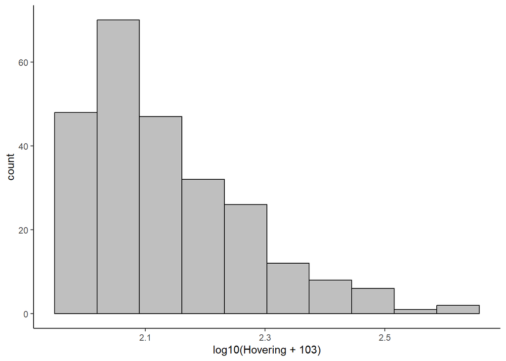

```r
ggplot(data, aes(x = log10(Hovering + 103)))+
  geom_histogram(bins = 10, fill = grey(0.75), color="black")
```

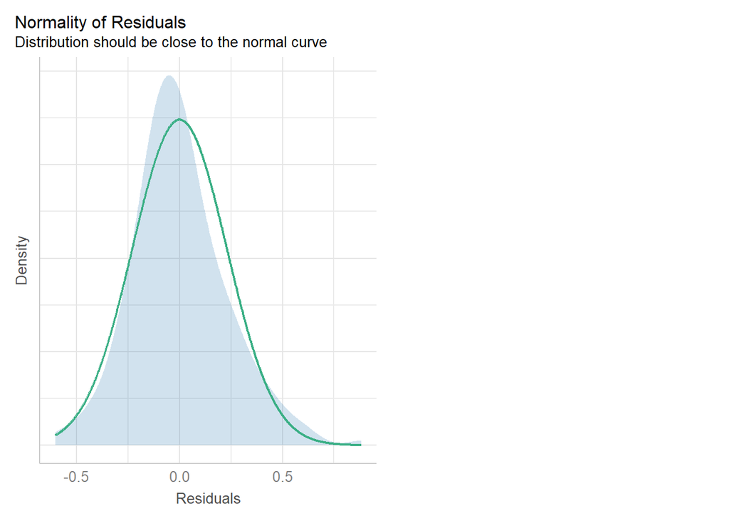

```r
mHovering <- lmer(log(Hovering+103)~Tank + Time + Filter + (1|Fish), data = data)
check_model(mHovering, check = "normality")
```

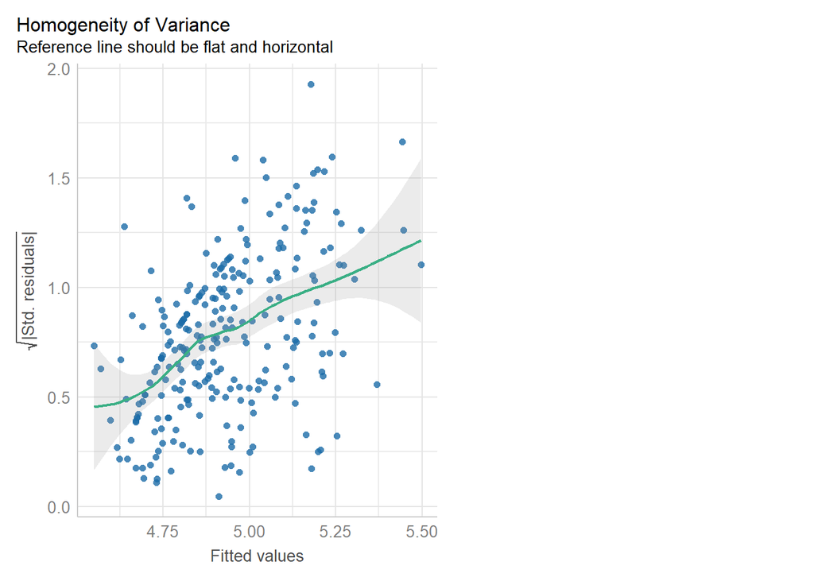

```r
check_model(mHovering, check = "homogeneity")
```

But anyway the fit is not good with an increase of variance in residuals with fitted values.

**Linear model**

Y variable = amount of time spent hovering during a trial.

Only considering positive hovering data Y > 0

```
[1] "check constant variance over fitted values"
```

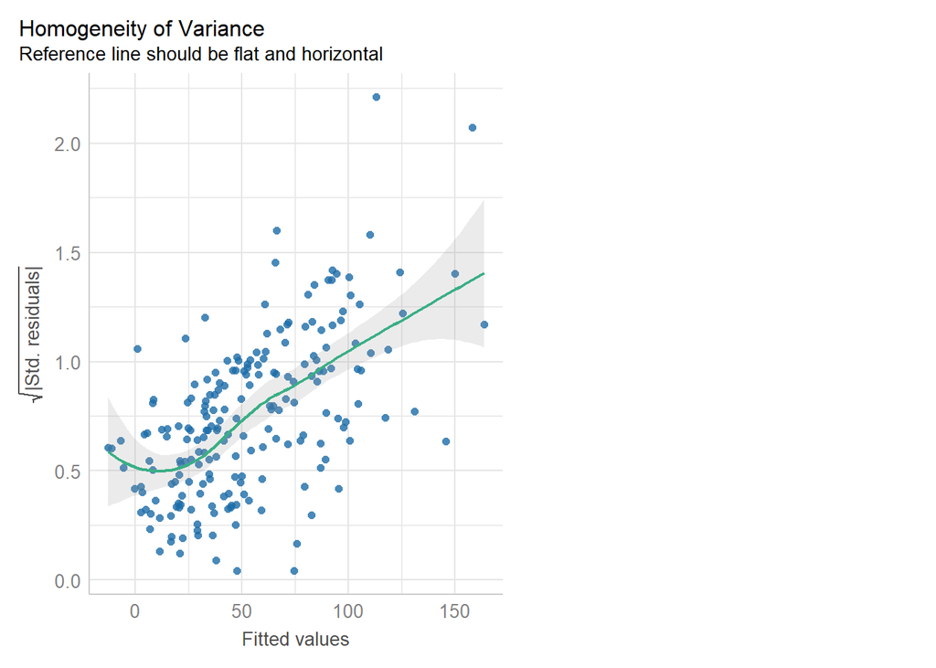

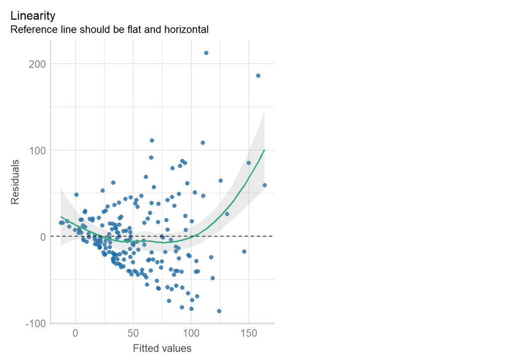

```
[1] "Normality of Hovering"
```

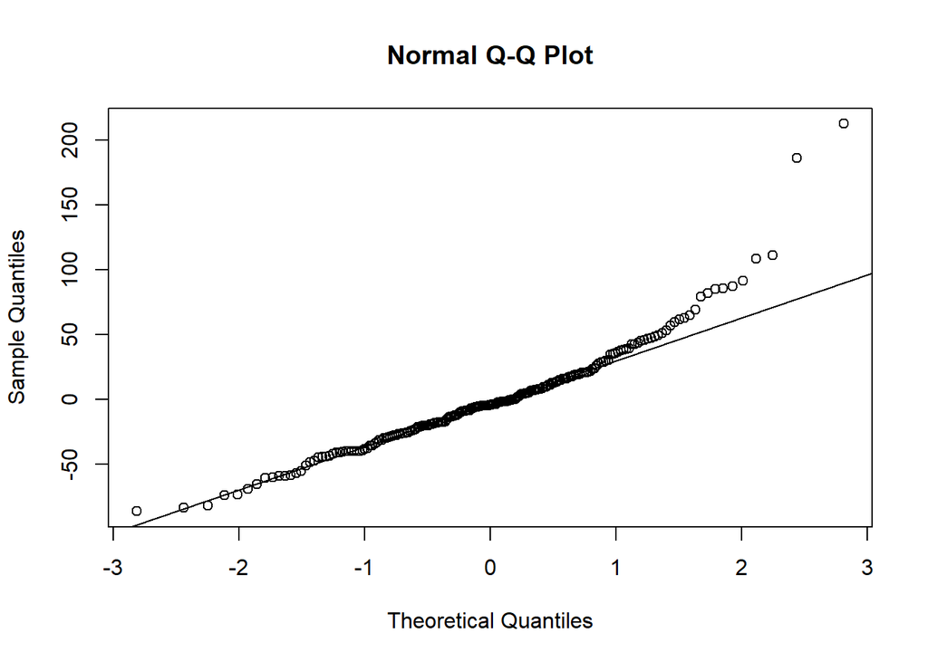

```
[1] "Normality random residuals"
```

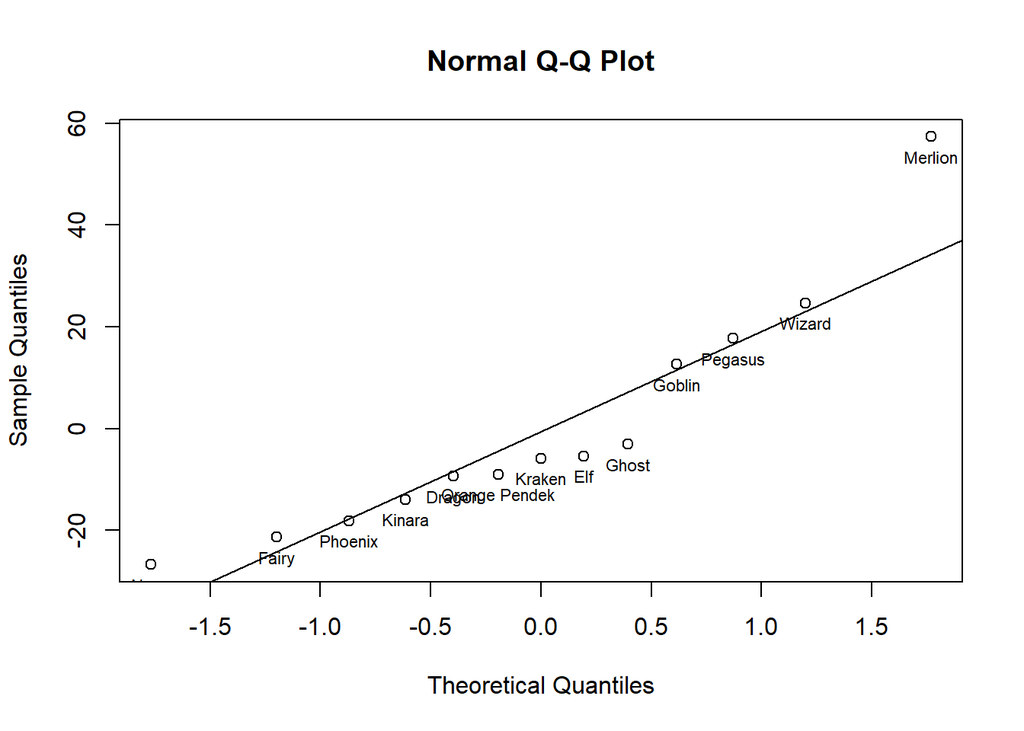

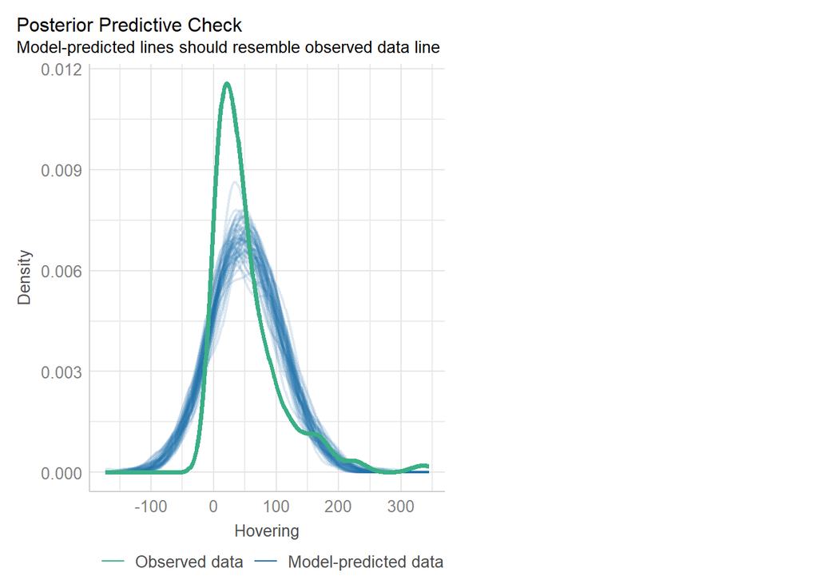

```r
mHovering <- lmer(Hovering ~ Tank + Time + Filter + (1|Fish), data = data2)
lm_diagnosis(mHovering)
```

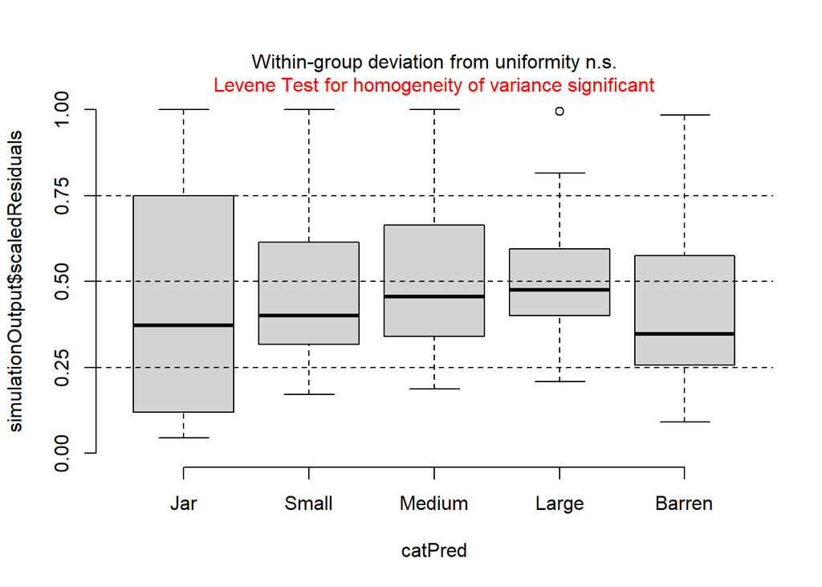

```r
plotResiduals(mHovering, form =  data2$Tank)
```

Problem homogeneity of variance, increase of residual variance with fitted values.

**Linear model with WLS**

In Weighted Least Squares (WLS, each observation is given a weight inversely proportional to its variance, helping to stabilize the variance across the fitted values.

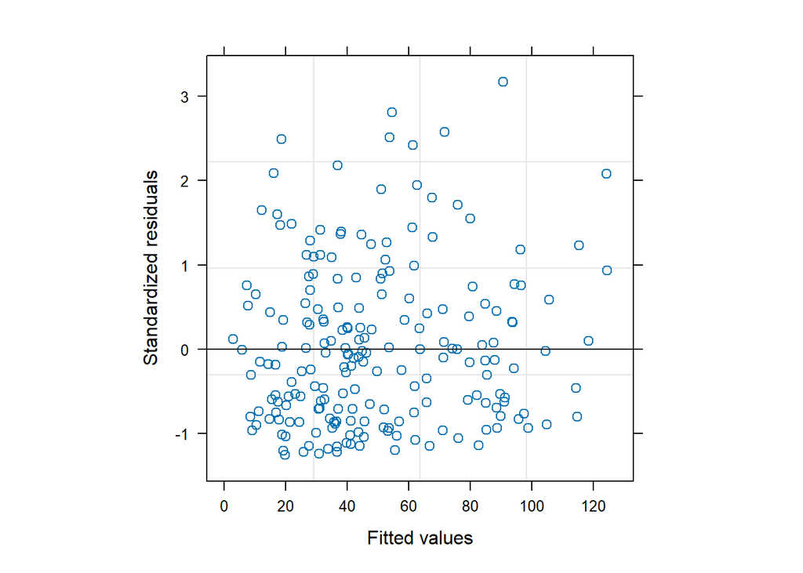

```r
mHovering <- lme(Hovering ~ Tank + Time + Filter, random = ~1 | Fish, data = data2, weights = varPower(), control = lmeControl(maxIter = 20000))
plot(mHovering, resid(., type = "pearson") ~ fitted(.), aspect = 1, pch = 21, abline = 0)
```

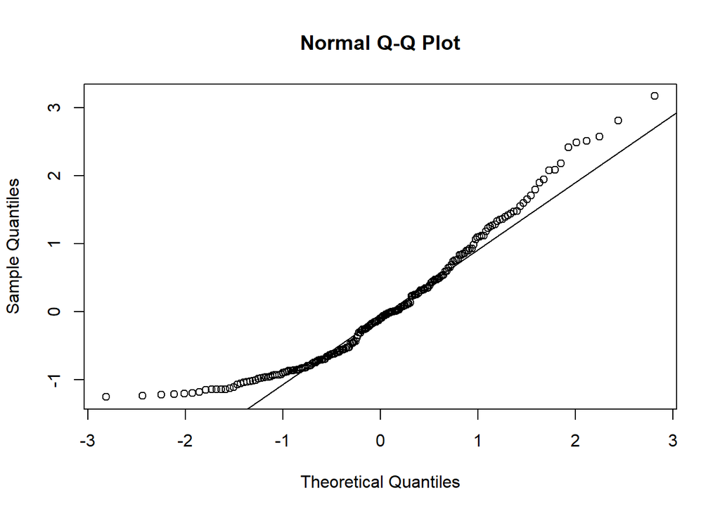

```r
qqnorm(resid(mHovering, type = "pearson"))
qqline(resid(mHovering, type = "pearson"))
```

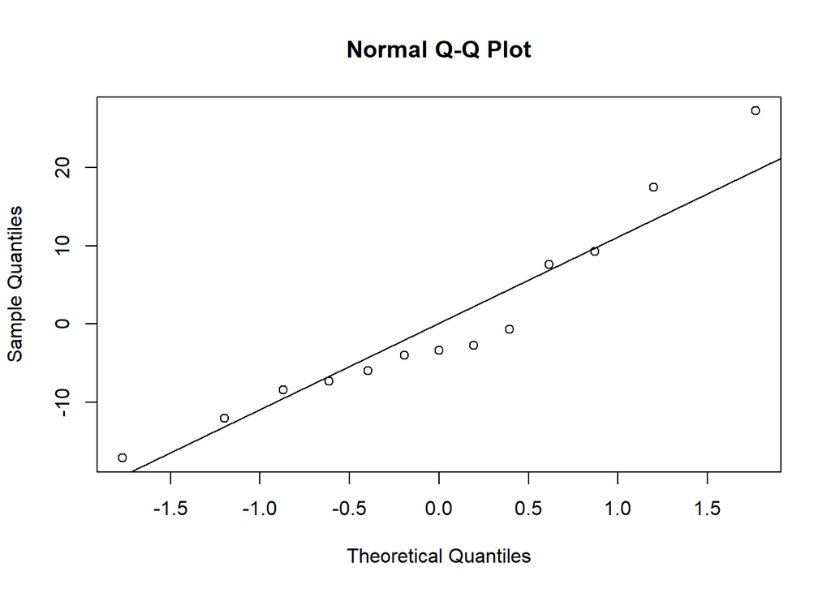

```r
ranefPlot <- ranef(mHovering, level = 1)
qqnorm(ranefPlot$`(Intercept)`)
qqline(ranefPlot$`(Intercept)`)
```

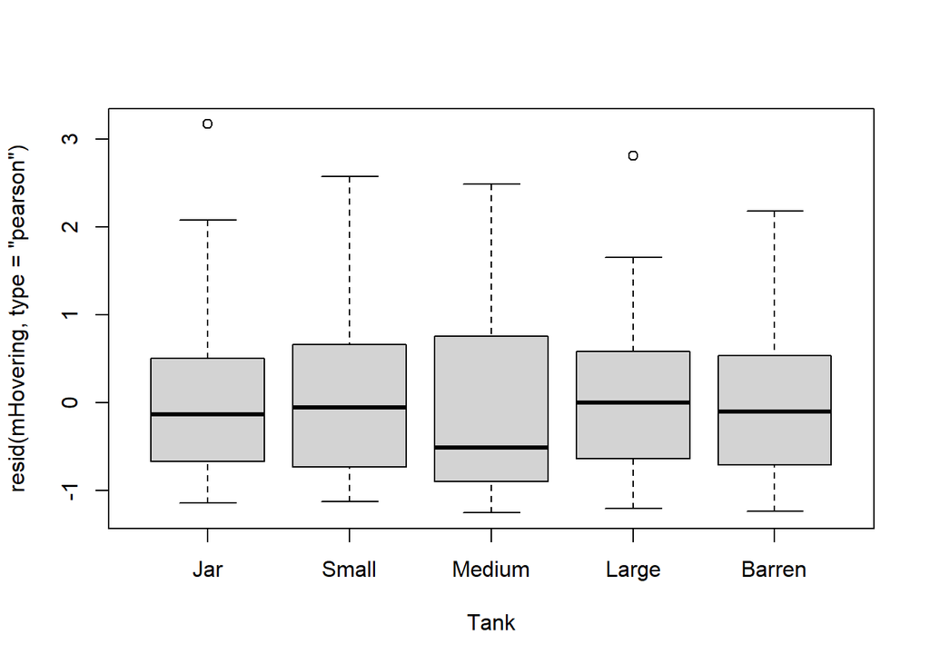

```r
boxplot(resid(mHovering, type = "pearson")~ Tank, data =  data2)
```

The normality is not great but ANOVA are robust to the assumption of normality.

However, the model is not working when including Order. The nlme package does not handle rank-deficient models. The lmer does not handle increasing error variance with fitted values automatically. On the next tab, I tried to implement increasing error variance with fitted values using lmer package.

**Ajusted weigthts lmer**

**Weights based on residual variance**

```r
mHovering <- lmer(Hovering ~ Tank + Time + Filter + Order + (1 | Fish), data = data2)
```

```
fixed-effect model matrix is rank deficient so dropping 1 column / coefficient
```

```r
anova(mHovering, ddf = "Kenward-Roger", type = 2)
```

```
Type II Analysis of Variance Table with Kenward-Roger's method
       Sum Sq Mean Sq NumDF  DenDF F value    Pr(>F)
Tank    91550 22887.5     4 186.16 12.5389 4.715e-09 ***
Time    10552  3517.2     3 180.56  1.9272    0.1268
Filter   4506  4505.8     1 137.88  2.4688    0.1184
Order   15931  5310.2     3 184.03  2.9095    0.0359 *
---
Signif. codes:  0 '***' 0.001 '**' 0.01 '*' 0.05 '.' 0.1 ' ' 1
```

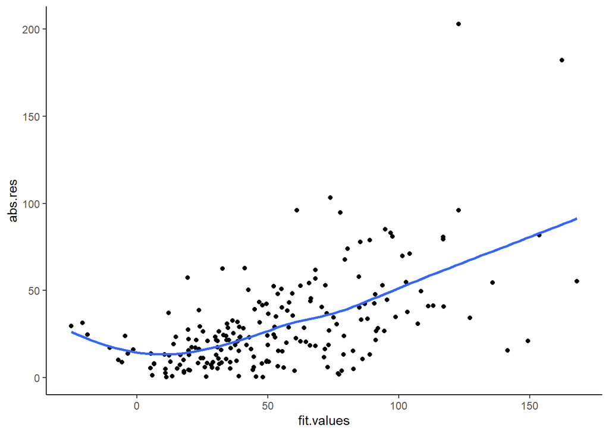

```r
# calculating weights
weights_hovering <- data.frame(abs.res = abs(residuals(mHovering)),
                               fit.values = fitted(mHovering))
ggplot(data = weights_hovering , aes(y = abs.res, x = fit.values)) +
  geom_point()+
  geom_smooth(method = "loess", se = FALSE)
```

```r
var_model <- lm(abs.res ~ fit.values + I(fit.values^2), data = weights_hovering)
var_model2 <- lm(abs.res ~ fit.values, data = weights_hovering)
AIC(var_model, var_model2)
```

```
           df      AIC
var_model   4 1855.309
var_model2  3 1859.412
```

```r
# A quadratic relationship seems more appropriate to predict the residuals from the fitted values
weights_hovering$var <- predict(var_model)^2
# Calculate weights as the inverse of the variance estimate
weights_hovering$weights <- 1 / weights_hovering$var
# The higher the variance, the less weight.
# So less weight/importance given to high fitted values because they are less reliable = they have a strong error associated to them
mHovering2 <- lmer(Hovering ~ Tank + Time + Filter + Order + (1 | Fish), data = data2,
                  weights = weights_hovering$weights)
```

```
fixed-effect model matrix is rank deficient so dropping 1 column / coefficient
```

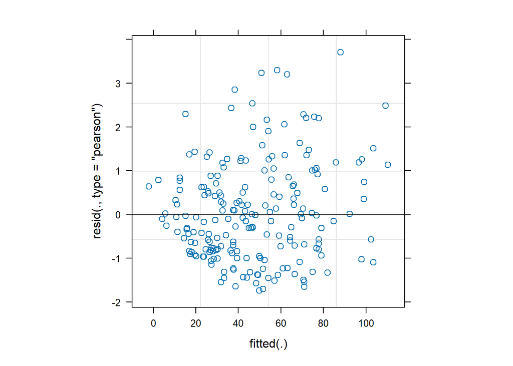

```r
plot(mHovering2, resid(., type = "pearson") ~ fitted(.), aspect = 1, pch = 21, abline = 0)
```

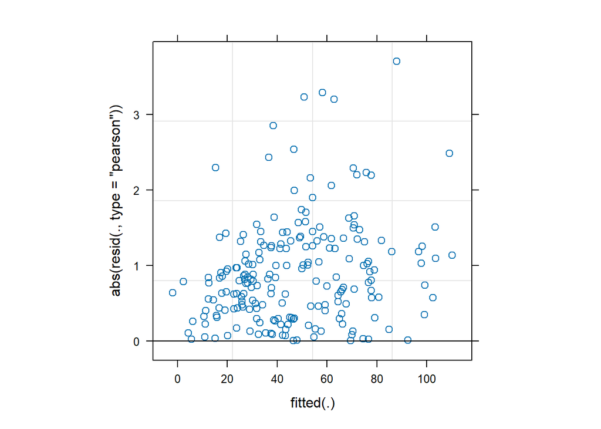

```r
plot(mHovering2, abs(resid(., type = "pearson")) ~ fitted(.), aspect = 1, pch = 21, abline = 0)
```

```r
anova(mHovering2, ddf = "Kenward-Roger", type = 2)
```

```
Type II Analysis of Variance Table with Kenward-Roger's method
         Sum Sq Mean Sq NumDF   DenDF F value  Pr(>F)
Tank   -27.6017 -6.9004     4  7.7532 -4.6262 1.00000
Time    10.2470  3.4157     3 17.9996  2.3768 0.10384
Filter   4.5799  4.5799     1 20.8723  3.1916 0.08856 .
Order   12.0989  4.0330     3 16.5362  2.8028 0.07216 .
---
Signif. codes:  0 '***' 0.001 '**' 0.01 '*' 0.05 '.' 0.1 ' ' 1
```

It worked: No more increasing variance with fitted values. But negative SumSq values for Tank, how is it possible?

2nd trial with bigger weights

```r
weights_hovering$SE <- predict(var_model)
weights_hovering$weights2 <- 1 / weights_hovering$SE
mHovering3 <- lmer(Hovering ~ Tank + Time + Filter + Order + (1 | Fish), data = data2,
                  weights = weights_hovering$weights2)
```

```
fixed-effect model matrix is rank deficient so dropping 1 column / coefficient
```

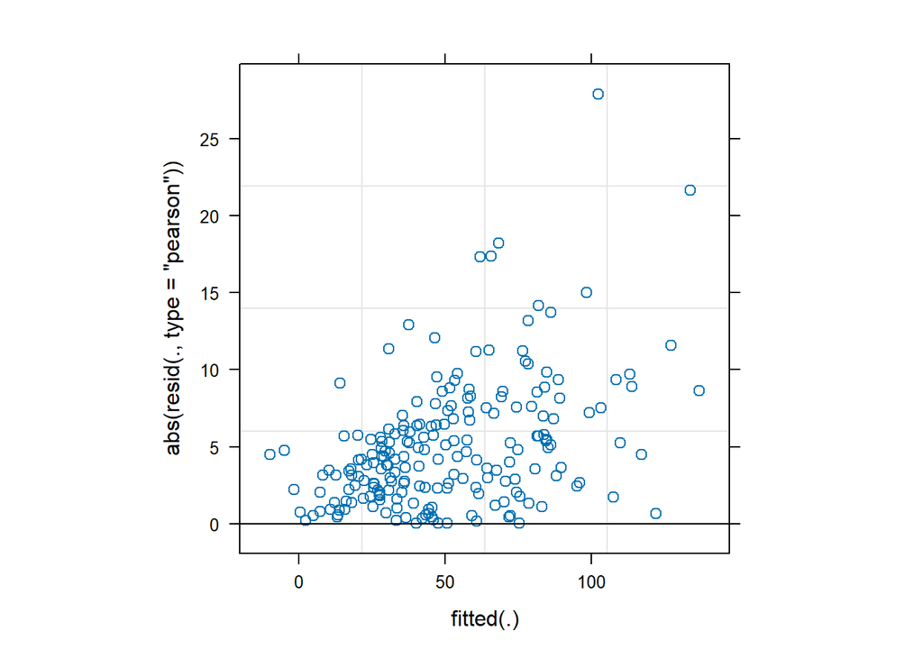

```r
plot(mHovering3, abs(resid(., type = "pearson")) ~ fitted(.), aspect = 1, pch = 21, abline = 0)
```

```r
anova(mHovering3, ddf = "Kenward-Roger", type = 2)
```

```
Type II Analysis of Variance Table with Kenward-Roger's method
       Sum Sq Mean Sq NumDF   DenDF F value    Pr(>F)
Tank   8620.5 2155.13     4  9.4919 45.5878 3.507e-06 ***
Time    410.2  136.74     3 11.0439  2.9093   0.08215 .
Filter  146.3  146.35     1 16.1805  3.1158   0.09640 .
Order   493.3  164.43     3 11.1074  3.4959   0.05294 .
---
Signif. codes:  0 '***' 0.001 '**' 0.01 '*' 0.05 '.' 0.1 ' ' 1
```

If using higher weights, no negative value of SS but it is not fixing the problem of residuals.

**Weights based on group tank**

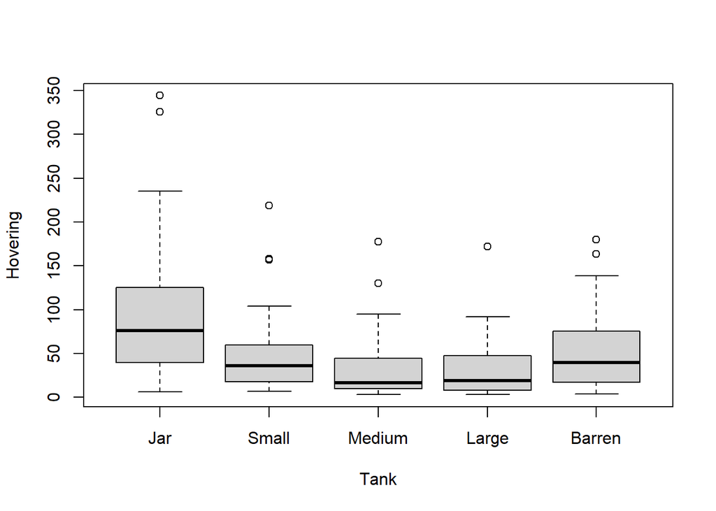

```r
with(data2, boxplot(Hovering ~ Tank))
```

```r
(tank.var <- with(data2,
                       tapply(Hovering,Tank, var)))
```

```
     Jar    Small   Medium    Large   Barren
5966.313 2078.774 1420.120 1058.654 1965.091
```

```r
# Creating weights inversely proportional to the estimated variances
weights <- with(data2, 1 / tank.var[Tank])
mHovering <- lmer(Hovering ~ Tank + Time + Filter + Order + (1 | Fish), data = data2, weights = weights)
```

```
fixed-effect model matrix is rank deficient so dropping 1 column / coefficient
```

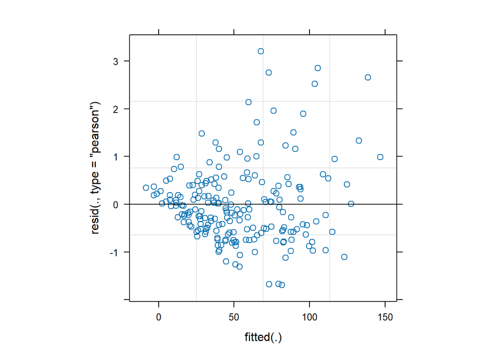

```r
plot(mHovering, resid(., type = "pearson") ~ fitted(.), aspect = 1, pch = 21, abline = 0)
```

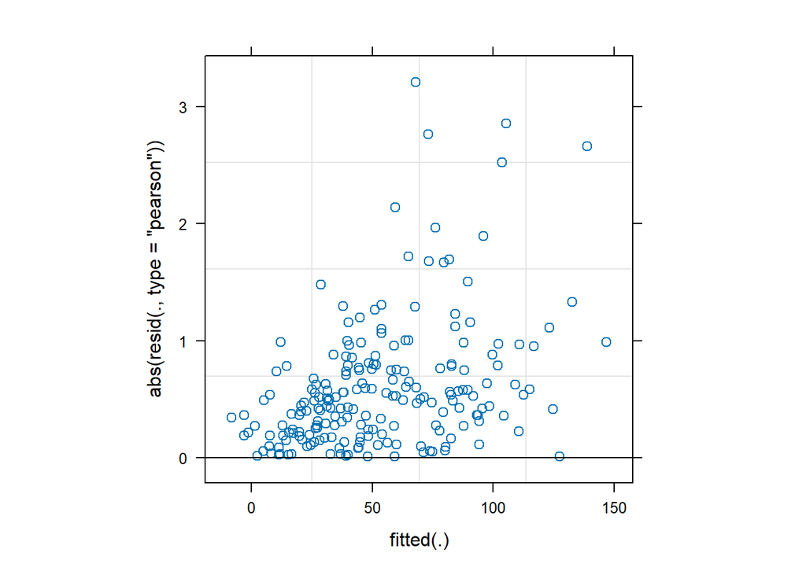

```r
plot(mHovering, abs(resid(., type = "pearson")) ~ fitted(.), aspect = 1, pch = 21, abline = 0)
```

```r
anova(mHovering, ddf = "Kenward-Roger", type = 2)
```

```
Type II Analysis of Variance Table with Kenward-Roger's method
         Sum Sq Mean Sq NumDF   DenDF F value  Pr(>F)
Tank   -15.6127 -3.9032     4  8.3071 -5.1931 1.00000
Time     7.6980  2.5660     3 16.5943  3.5329 0.03797 *
Filter   3.0877  3.0877     1 22.8958  4.2512 0.05075 .
Order    4.2242  1.4081     3 16.0998  1.9378 0.16395
---
Signif. codes:  0 '***' 0.001 '**' 0.01 '*' 0.05 '.' 0.1 ' ' 1
```

Again negative Sum of Squares and not fixing the problem in the residual variance